# ps5-markdown-plot

selina

2/13/2023

1. Load and check data

```r
getwd()
```

```
## [1] "/Users/yuanran/INFO201/Problemsets/PS5-markdown-plot"
```

```r
library(tidyverse)
gapminder <- read_delim("gapminder.csv.bz2")
```

(2). The *gapminder* data contained 13055 rows and 25 columns.

(3):

```r
gapminder %>%
  sample_n(5)
```

```
## # A tibble: 5 × 25
##   iso3  name  iso2  region sub-r…¹ inter…²  time total…³ ferti…⁴ lifeE…⁵ child…⁶
##   <chr> <chr> <chr> <chr>  <chr>   <chr>   <dbl>   <dbl>   <dbl>   <dbl>   <dbl>
## 1 HRV   Croa… HR    Europe Southe… <NA>     1965  4.28e6    2.1     66.5    NA
## 2 SUR   Suri… SR    Ameri… Latin … South …  1990  4.05e5    3.27    67.4    45
## 3 CZE   Czec… CZ    Europe Easter… <NA>     1994  1.03e7    1.44    73.0     9.4
## 4 CIV   Côte… CI    Africa Sub-Sa… Wester…  2013  2.21e7    4.92    54.9    96.9
## 5 RWA   Rwan… RW    Africa Sub-Sa… Easter…  1992  6.70e6    6.71    26.7   163.
## # … with 14 more variables: youthFemaleLiteracy <dbl>, youthMaleLiteracy <dbl>,
## #   adultLiteracy <dbl>, GDP_PC <dbl>, accessElectricity <dbl>,
## #   agriculturalLand <dbl>, agricultureTractors <dbl>, cerealProduction <dbl>,
## #   fertilizerHa <dbl>, co2 <dbl>, greenhouseGases <dbl>, co2_PC <dbl>,
## #   pm2.5_35 <dbl>, battleDeaths <dbl>, and abbreviated variable names
## #   ¹`sub-region`, ²`intermediate-region`, ³totalPopulation, ⁴fertilityRate,
## #   ⁵lifeExpectancy, ⁶childMortality
```

2. Descriptive statistics

(1). For 3-letter country code, there are 253 countries; for 2-letter country code, there are 249 countries; and for names, there are 250 countries.

(2). (a)

```r
gapminder %>%
  group_by(name, iso2) %>%
  summarise(n_distinct(iso2), n()) %>%
  arrange(desc(n()))
```

```
## # A tibble: 250 × 4
## # Groups:   name [250]
##    name                iso2  `n_distinct(iso2)` `n()`
##    <chr>               <chr>              <int> <int>
##  1 Afghanistan         AF                     1    60
##  2 Albania             AL                     1    60
##  3 Algeria             DZ                     1    60
##  4 American Samoa      AS                     1    60
##  5 Andorra             AD                     1    60
##  6 Angola              AO                     1    60
##  7 Anguilla            AI                     1     1
##  8 Antarctica          AQ                     1     1
##  9 Antigua and Barbuda AG                     1    60
## 10 Argentina           AR                     1    60
## # … with 240 more rows
```

```r
gapminder %>%
  group_by(name, iso3) %>%
  summarise(n_distinct(iso3), n()) %>%
  arrange(desc(n()))
```

```
## # A tibble: 253 × 4
## # Groups:   name [250]
##    name                iso3  `n_distinct(iso3)` `n()`
##    <chr>               <chr>              <int> <int>
##  1 Afghanistan         AFG                    1    60
##  2 Albania             ALB                    1    60
##  3 Algeria             DZA                    1    60
##  4 American Samoa      ASM                    1    60
##  5 Andorra             AND                    1    60
##  6 Angola              AGO                    1    60
##  7 Anguilla            AIA                    1     1
##  8 Antarctica          ATA                    1     1
##  9 Antigua and Barbuda ATG                    1    60
## 10 Argentina           ARG                    1    60
## # … with 243 more rows
```

(3).

```r
min <- gapminder %>%
  filter(!is.na(time)) %>%
  summarise(n = min(time))
```

```r
max <- gapminder %>%
  filter(!is.na(time)) %>%
  summarise(n = max(time))
```

The minimum year in the data is 1960 and the maximum is 2019.

3. CO2 emossions

```r
missing_co2 <- gapminder %>%
  filter(is.na(co2)) %>%
  group_by(time) %>%
  summarise(n())
```

```r
missing_co2pc <- gapminder %>%
  filter(is.na(co2_PC)) %>%
  group_by(time) %>%
  summarise(n())
```

(2).

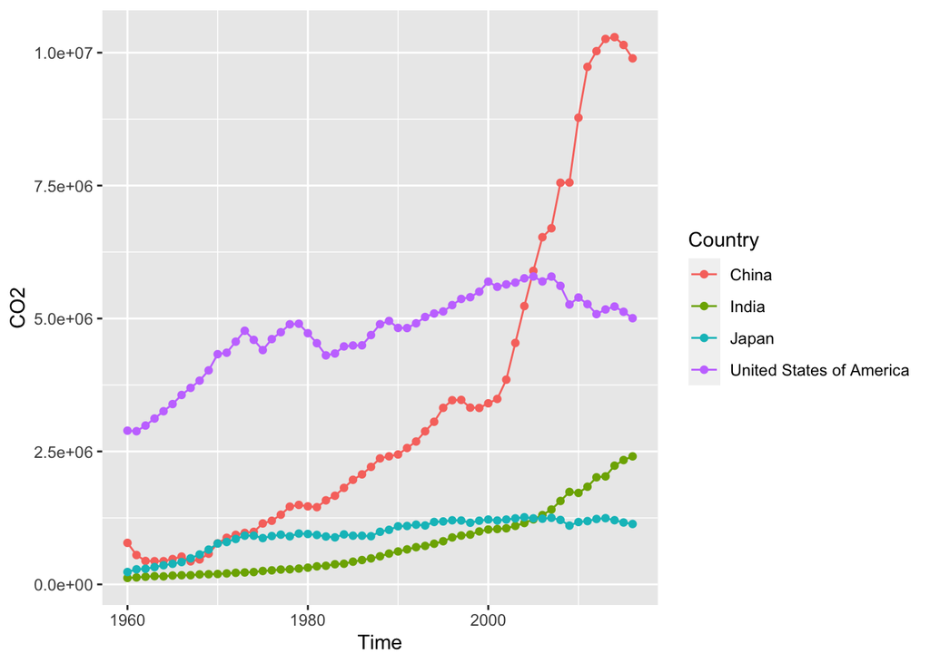

```r
gapminder %>%
  filter(!is.na(co2)) %>%
  filter(iso2 == "US" |
           name == "China" |
           name == "India" |
           name == "Japan") %>%
  ggplot(aes(time, co2, col=factor(name))) +
  geom_line() +
  geom_point() +
  labs(x = "Time", y = "CO2",
       col = "Country")
```

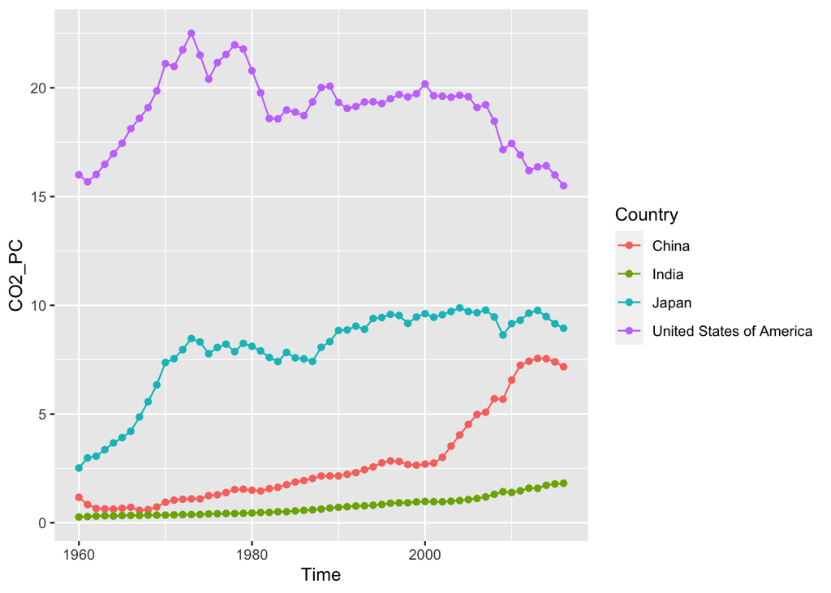

```r
gapminder %>%
  filter(!is.na(co2_PC)) %>%
  filter(iso2 == "US" |
           name == "China" |
           name == "India" |
           name == "Japan") %>%
  ggplot(aes(time, co2_PC, col=factor(name))) +
  geom_line() +
  geom_point() +
  labs(x = "Time", y = "CO2_PC",
       col = "Country")
```

There is a huge different between emission per capital than just emission. U.S now has the most ammount of emission per capital than other three countries.

```r
gapminder %>%
  filter(!is.na(co2_PC),
         time == 2016) %>%
  group_by(region) %>%
  summarize(mean(co2_PC))
```

```
## # A tibble: 6 × 2
##   region   `mean(co2_PC)`
##   <chr>             <dbl>
## 1 Africa             1.20
## 2 Americas           4.80
## 3 Asia               6.47
## 4 Europe             6.64
## 5 Oceania            4.57
## 6 <NA>              19.4
```

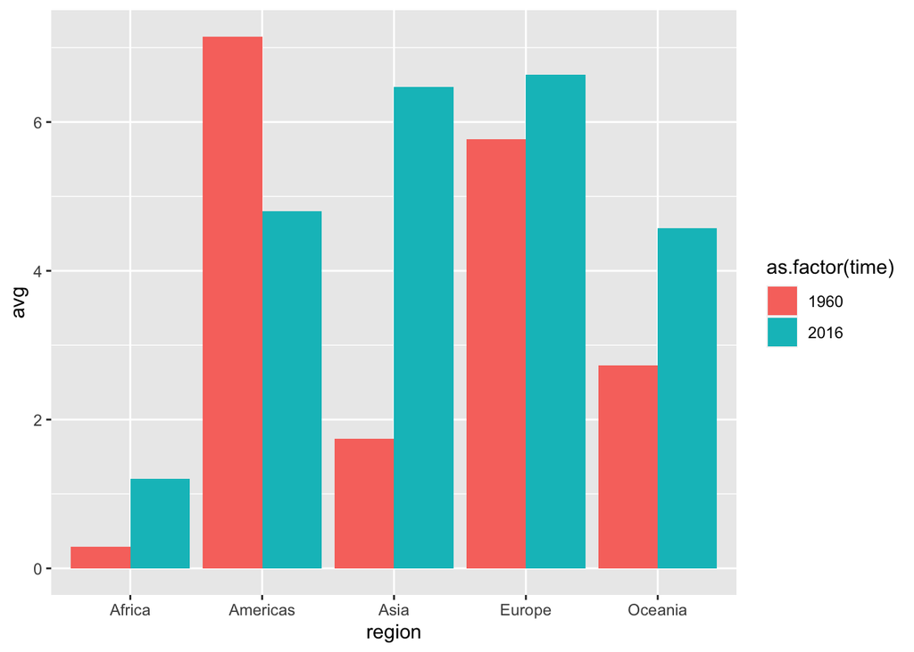

```r
gapminder %>%
  filter(time %in% c(1960, 2016),
         !is.na(co2_PC),
         !is.na(region)) %>%
  group_by(region, time) %>%
  summarize(avg = mean(co2_PC)) %>%
  ggplot(aes(region, avg, fill = as.factor(time))) +
  geom_col(position = "dodge")
```

```r
gapminder %>%
  filter(!is.na(co2_PC),
         !is.na(region)) %>%
  group_by(region, name, .add = TRUE) %>%
  summarize(n()) %>%
  group_split(region)
```

```
## <list_of<
##   tbl_df<
##     region: character
##     name  : character
##     n()   : integer
##   >
## >[5]>
## [[1]]
## # A tibble: 54 × 3
##    region name                     `n()`
##    <chr>  <chr>                    <int>
##  1 Africa Algeria                     57
##  2 Africa Angola                      57
##  3 Africa Benin                       57
##  4 Africa Botswana                    45
##  5 Africa Burkina Faso                57
##  6 Africa Burundi                     55
##  7 Africa Cabo Verde                  57
##  8 Africa Cameroon                    57
##  9 Africa Central African Republic    57
## 10 Africa Chad                        57
## # … with 44 more rows
##
## [[2]]
## # A tibble: 42 × 3
##    region   name                             `n()`
##    <chr>    <chr>                            <int>
##  1 Americas Antigua and Barbuda                 57
##  2 Americas Argentina                           57
##  3 Americas Aruba                               57
##  4 Americas Bahamas                             57
##  5 Americas Barbados                            57
##  6 Americas Belize                              57
##  7 Americas Bermuda                             57
##  8 Americas Bolivia (Plurinational State of)    57
##  9 Americas Brazil                              57
## 10 Americas Canada                              57
## # … with 32 more rows
##
## [[3]]
```

[output cut: 36 more lines]

```
##  2 Oceania Fiji                                57
##  3 Oceania French Polynesia                    57
##  4 Oceania Kiribati                            56
##  5 Oceania Marshall Islands                    27
##  6 Oceania Micronesia (Federated States of)    25
##  7 Oceania Nauru                               53
##  8 Oceania New Caledonia                       57
##  9 Oceania New Zealand                         57
## 10 Oceania Palau                               57
## 11 Oceania Papua New Guinea                    57
## 12 Oceania Samoa                               57
## 13 Oceania Solomon Islands                     57
## 14 Oceania Tonga                               57
## 15 Oceania Tuvalu                              27
## 16 Oceania Vanuatu                             55
```

4. GDP per capital

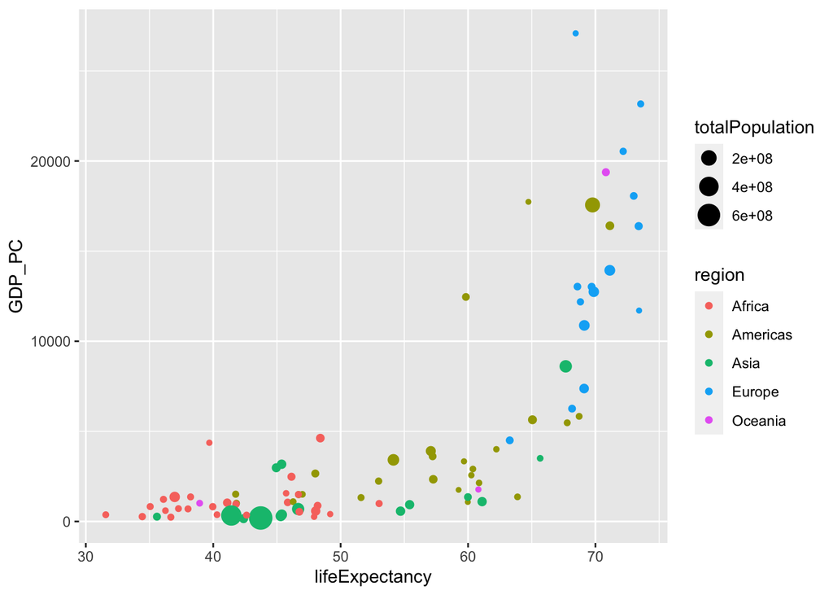

```r
gapminder %>%
  filter(time == 1960,
         !is.na(GDP_PC),
         !is.na(lifeExpectancy)) %>%
  ggplot() +
  geom_point(aes(lifeExpectancy, GDP_PC, col = region, size = totalPopulation))
```

This scatterplot shows that European countries have relatively higher GDP per capital and higher life expectancy. Asian countries have bigger size.

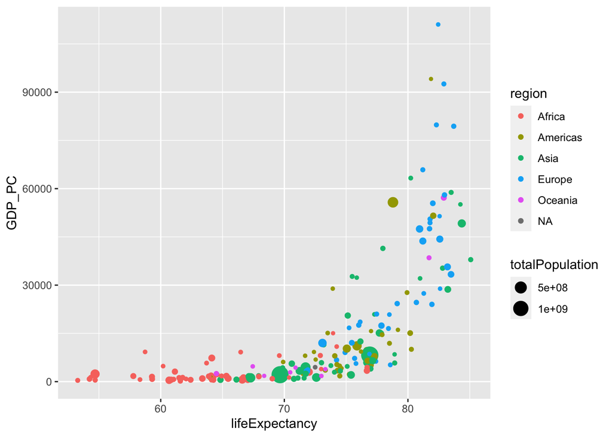

```r
gapminder %>%
  filter(time == 2019,
         !is.na(GDP_PC),
         !is.na(lifeExpectancy)) %>%
  ggplot() +
  geom_point(aes(lifeExpectancy, GDP_PC, col = region, size = totalPopulation))
```

```r
gapminder %>%
  filter(!is.na(lifeExpectancy),
         !is.na(region),
         time == 1960) %>%
  group_by(region) %>%
  summarize(avg = mean(lifeExpectancy))
```

```
## # A tibble: 5 × 2
##   region     avg
##   <chr>    <dbl>
## 1 Africa    41.5
## 2 Americas  58.6
## 3 Asia      51.6
## 4 Europe    68.3
## 5 Oceania   56.4
```

```r
gapminder %>%
  filter(!is.na(lifeExpectancy),
         !is.na(region),
         time == 2019) %>%
  group_by(region) %>%
  summarize(avg = mean(lifeExpectancy))
```

```
## # A tibble: 5 × 2
##   region     avg
##   <chr>    <dbl>
## 1 Africa    64.1
## 2 Americas  75.8
## 3 Asia      74.6
## 4 Europe    79.4
## 5 Oceania   73.5
```

I think the result pretty much matches the graphs that I computed above.

```r
gapminder %>%
  group_by(region, time) %>%
  filter(!is.na(lifeExpectancy),
         !is.na(region)) %>%
  summarize(avg = mean(lifeExpectancy)) %>%
  arrange(start = 1960, end = 2019,
          rank(avg)) %>%
  ungroup() %>%
  mutate(growth = avg - lag(avg)) %>%
  group_split(region)
```

```
## <list_of<
##   tbl_df<
##     region: character
##     time  : double
##     avg   : double
##     growth: double
##   >
## >[5]>
## [[1]]
## # A tibble: 60 × 4
##    region  time   avg growth
##    <chr>  <dbl> <dbl>  <dbl>
##  1 Africa  1960  41.5 NA
##  2 Africa  1961  41.9  0.455
##  3 Africa  1962  42.4  0.451
##  4 Africa  1963  42.8  0.447
##  5 Africa  1964  43.3  0.443
##  6 Africa  1965  43.7  0.440
##  7 Africa  1966  44.1  0.440
##  8 Africa  1967  44.6  0.442
##  9 Africa  1968  45.0  0.447
## 10 Africa  1969  45.5  0.454
## # … with 50 more rows
##
## [[2]]
## # A tibble: 60 × 4
##    region    time   avg growth
##    <chr>    <dbl> <dbl>  <dbl>
##  1 Americas  1960  58.6 0.226
##  2 Americas  1961  59.1 0.105
##  3 Americas  1962  59.5 0.0839
##  4 Americas  1963  60.0 0.210
##  5 Americas  1964  60.4 0.235
##  6 Americas  1965  61.0 0.161
##  7 Americas  1966  61.2 0.138
##  8 Americas  1967  61.5 0.139
##  9 Americas  1968  61.9 0.295
## 10 Americas  1969  62.3 0.213
## # … with 50 more rows
##
```

[output cut: 32 more lines]

```
## [[5]]
## # A tibble: 60 × 4
##    region   time   avg growth
##    <chr>   <dbl> <dbl>  <dbl>
##  1 Oceania  1960  56.4 0.264
##  2 Oceania  1961  56.8 0.0614
##  3 Oceania  1962  57.2 0.236
##  4 Oceania  1963  57.6 0.159
##  5 Oceania  1964  58.0 0.126
##  6 Oceania  1965  58.4 0.148
##  7 Oceania  1966  58.8 0.0460
##  8 Oceania  1967  59.3 0.136
##  9 Oceania  1968  59.6 0.0804
## 10 Oceania  1969  60.0 0.0888
## # … with 50 more rows
```

I can see that for all of the continents, there is growth in life expectancy within the year of 1960 to 2019.

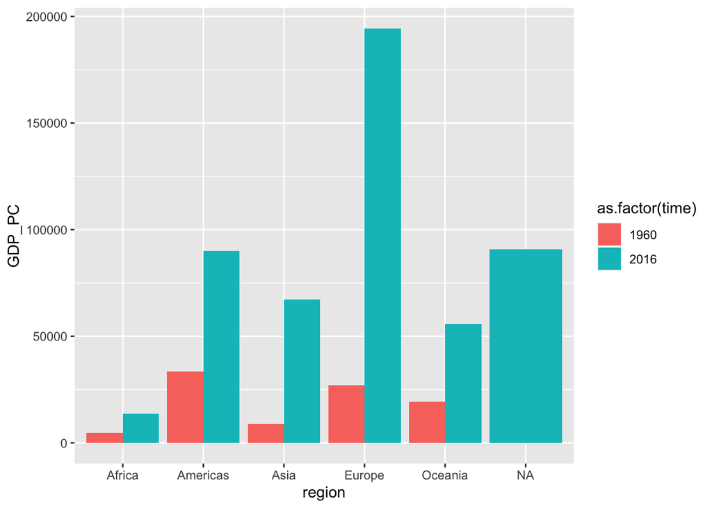

```r
gapminder %>%
  filter(time %in% c(1960, 2016),
         !is.na(GDP_PC)) %>%
  ggplot(aes(region, GDP_PC, fill = as.factor(time))) +
  geom_col(position = "dodge")
```

```r
gapminder %>%
  filter(time == 1960,
         !is.na(lifeExpectancy),
         !is.na(region)) %>%
  mutate(rank = rank(desc(lifeExpectancy))) %>%
  select(name, lifeExpectancy, rank) %>%
  filter(name == "United States of America")
```

```
## # A tibble: 1 × 3
##   name                     lifeExpectancy  rank
##   <chr>                             <dbl> <dbl>
## 1 United States of America           69.8    17
```

```r
gapminder %>%
  filter(time == 2019,
         !is.na(lifeExpectancy),
         !is.na(region)) %>%
  mutate(rank = rank(desc(lifeExpectancy))) %>%
  select(name, lifeExpectancy, rank) %>%
  filter(name == "United States of America")
```

```
## # A tibble: 1 × 3
##   name                     lifeExpectancy  rank
##   <chr>                             <dbl> <dbl>
## 1 United States of America           78.8    46
```

```r
gapminder %>%
  filter(time == 1960,
         !is.na(lifeExpectancy),
         !is.na(region)) %>%
  mutate(rank = rank(desc(lifeExpectancy))) %>%
  mutate(relative = rank /n_distinct(name)) %>%
  select(name, lifeExpectancy, rank, relative) %>%
  filter(name == "United States of America")
```

```
## # A tibble: 1 × 4
##   name                     lifeExpectancy  rank relative
##   <chr>                             <dbl> <dbl>    <dbl>
## 1 United States of America           69.8    17   0.0904
```

```r
gapminder %>%
  filter(time == 2019,
         !is.na(lifeExpectancy),
         !is.na(region)) %>%
  mutate(rank = rank(desc(lifeExpectancy))) %>%
  mutate(relative = rank /n_distinct(name)) %>%
  select(name, lifeExpectancy, rank, relative) %>%
  filter(name == "United States of America")
```

```
## # A tibble: 1 × 4
##   name                     lifeExpectancy  rank relative
##   <chr>                             <dbl> <dbl>    <dbl>
## 1 United States of America           78.8    46    0.235
```